# Analysis between area of depriviation and gini coefficient

This project aims to explore the relationship between socioeconomic deprivation and income inequality across the United States. Using datasets on the Area Deprivation Index (ADI) and the Gini Index, we analyze their distributions and correlations to uncover patterns and insights. The analysis is structured as follows:

1. **Analysis of Area Deprivation Index Percent datasets**: Examining the distribution of ADI values across states.
2. **Analysis of GINI Data**: Investigating income inequality using the Gini Index.
3. **Analysis of merged_data**: Combining ADI and Gini datasets to study their relationship.

## Analysis of Area Deprivation Index Percent datasets

In this section, we will analyze the Area Deprivation Index Percent (ADI%) dataset to understand the distribution of socioeconomic deprivation across states. We will visualize the data using ridge plots to highlight disparities and patterns in deprivation levels.

```python
# read the csv file inside data folder and print the first 5 rows
import pandas as pd
adi_data = pd.read_csv('data/adi_by_county.csv')

# rename geo_id to GEO_ID
adi_data = adi_data.rename(columns={'geo_id': 'GEO_ID'})
print(adi_data.head())
```

```
         GEO_ID  state_fips_code  county_fips_code     county_name state_name  \
0  05000US01001                1              1001  Autauga County    Alabama
1  05000US01001                1              1001  Autauga County    Alabama
2  05000US01001                1              1001  Autauga County    Alabama
3  05000US01003                1              1003  Baldwin County    Alabama
4  05000US01003                1              1003  Baldwin County    Alabama

  state  year  area_deprivation_index_percent
0    AL  2020                              29
1    AL  2019                              29
2    AL  2018                              27
3    AL  2018                              20
4    AL  2020                              16
```

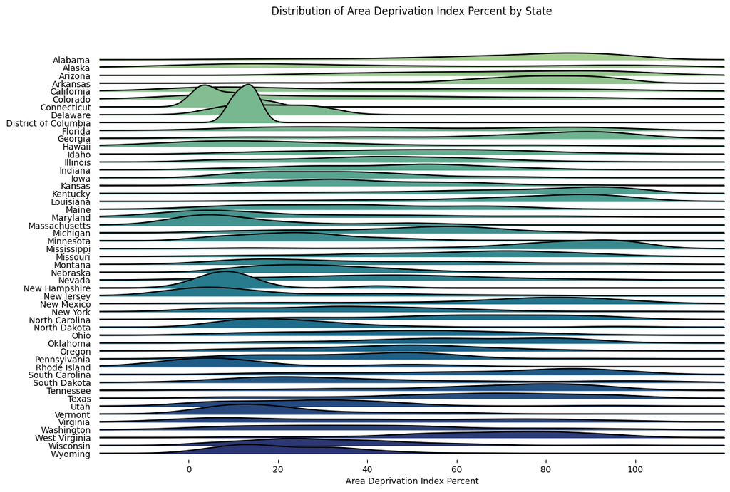

```python
# Visualize the distribution of area_deprivation_index_percent column of each state using ridge lines
import seaborn as sns
import matplotlib.pyplot as plt
from joypy import joyplot

plt.figure(figsize=(12, 8))
joyplot(
    data=adi_data[['state_name', 'area_deprivation_index_percent']],
    by='state_name',
    figsize=(12, 8),
    title='Distribution of Area Deprivation Index Percent by State',
    colormap=sns.color_palette("crest", as_cmap=True)
)
plt.xlabel('Area Deprivation Index Percent')
plt.savefig('adi_distribution_by_state.png')
plt.show()
```

The above visualization provides a detailed look at the distribution of Area Deprivation Index Percent (ADI%) across states, highlighting regional disparities and patterns in socioeconomic disadvantage.

Across states, the Area Deprivation Index Percent (ADI%) distributions show substantial geographic disparity in socioeconomic disadvantage: some states—particularly in the South and parts of the Midwest—display broader, right-skewed distributions with large density mass at higher ADI% values, indicating more communities experiencing high deprivation, while many Northeastern and Western states show tighter distributions clustered at lower ADI%, reflecting generally less deprived neighborhoods; states like Mississippi, Louisiana, West Virginia, and New Mexico exhibit pronounced peaks above the national mid-range, signaling widespread structural disadvantage, whereas states such as Utah, Minnesota, and Massachusetts have distributions concentrated toward the lower end, suggesting more uniformly advantaged areas; overall, the chart reveals that deprivation is not evenly distributed across the United States but instead follows strong regional patterns tied to historical, economic, and demographic factors.

## Analysis of GINI Data

In this section, we will analyze the Gini Index dataset to understand income inequality across states. Ridge plots will be used to visualize the distribution of Gini values, highlighting disparities and patterns in income inequality levels.

```python
gini_data = pd.read_csv('data/gini_index_by_state.csv')
#reanme NAME to state_name
gini_data = gini_data.rename(columns={'NAME': 'state_name'})
print(gini_data.head())
```

```
        GEO_ID state_name  B19083_001E  Year
0  0400000US01    Alabama       0.4768  2017
1  0400000US01    Alabama       0.4735  2011
2  0400000US01    Alabama       0.4752  2013
3  0400000US01    Alabama       0.4720  2010
4  0400000US01    Alabama       0.4847  2016
```

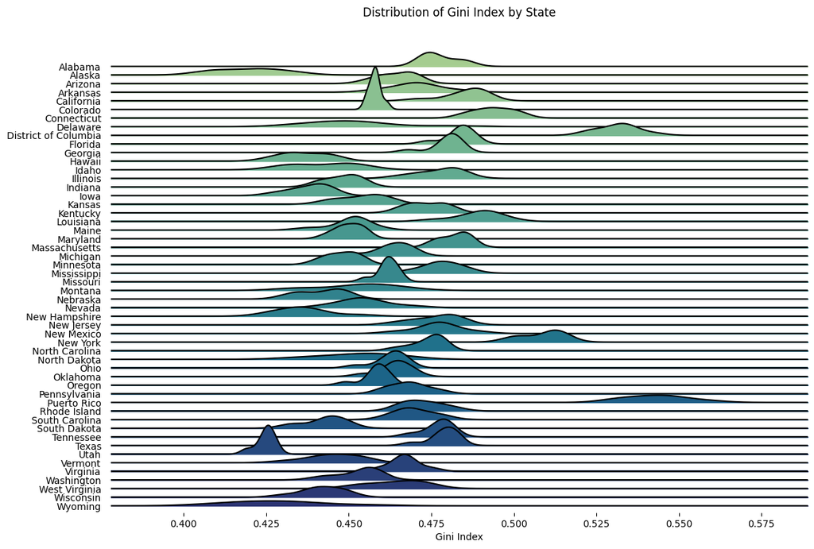

```python
# Visualize the distribution of Gini Index by state using ridge lines
plt.figure(figsize=(12, 8))
joyplot(
    data=gini_data[['state_name', 'B19083_001E']],
    by='state_name',
    figsize=(12, 8),
    title='Distribution of Gini Index by State',
    colormap=sns.color_palette("crest", as_cmap=True)
    )
plt.xlabel('Gini Index')
plt.savefig('gini_distribution_by_state.png')
plt.show()
```

The above visualization provides a detailed look at the distribution of the Gini Index across states, highlighting disparities and patterns in income inequality.

Across states, the Gini Index distributions show meaningful but more compressed variation compared to ADI, reflecting differences in income inequality rather than neighborhood deprivation; many states cluster tightly around values between 0.44 and 0.48, indicating moderate inequality, while a subset—especially large, diverse, or economically polarized states such as New York, California, Florida, Louisiana, and Texas—display wider or right-shifted distributions toward higher Gini values, signaling more pronounced income disparities; in contrast, states like Utah, Idaho, Wyoming, and Iowa exhibit narrower distributions at the lower end, consistent with more equal income structures; overall, the chart highlights that while inequality exists nationwide, certain states demonstrate heavier right tails or multi-peaked patterns that suggest substantial within-state heterogeneity driven by urban-rural divides, demographic composition, and industrial structures.